# Social Simon Effect in Movement Trajectories - Data Analysis

This is a complete script for analyzing the data collected in the mouse-tracking Social Simon study and reported in the article (submitted). The study consisted of 3 experiments:

- experiment 1: individual Simon task, in which a person had to respond to two colors by moving right or left and clicking on a response “button”
- experiment 2: individual Go/NoGo version of the Simon task, in which a person had to respond to only one of the two colors
- experiment 3: joint Simon task, in which two people carried out the task together, responding each to one of the colors; this experiment included two conditions:
  - Online condition: participants could see each other’s mouse cursors
  - Offline condition: participants could see only their own mouse cursor

This script covers data preprocessing, data analysis reported in the article and some additional analysis.

# Data pre-processing

First we get summary statistics for the participants in all experiments.

```r
participants <- read.csv("./data/Participant_stats.csv")

participants %>% group_by(experiment) %>%
    dplyr::summarize(mean.age = mean(age),
              max.age = max(age),
              min.age = min(age)) ->
    age.stats
participants %>% group_by(experiment, sex) %>%
    dplyr::summarize(gender.count = n()) -> gender.stats
kable(age.stats)
```

| experiment | mean.age | max.age | min.age |
| --- | --- | --- | --- |
| exp1 | 23.90000 | 30 | 19 |
| exp2 | 26.52632 | 51 | 20 |
| exp3 | 24.36667 | 54 | 18 |

```r
kable(gender.stats)
```

| experiment | sex | gender.count |
| --- | --- | --- |
| exp1 | F | 14 |
| exp1 | M | 6 |
| exp2 | F | 17 |
| exp2 | M | 2 |
| exp3 | F | 48 |
| exp3 | M | 12 |

Then we save the screen dimensions and relevant coordinates used in the experiment.

```r
# save experiment parameter values
screen.width <- 1920
screen.height <- 1080
start.boundary <- 988 # upper boundary of the start button
response.boundary <- 128 # lower boundary of response boxes
stim.boundary <- 820 # the y-coord that needed to be crossed for stimulus to appear
```

We then perform the following steps:

**Step 1** Load the data and reformat it for easier processing.

The data was recorded in a wide format, in which each row represented a particular trial. We transform it into a long format, in which each row corresponds to a particular timestamp and x,y-coordinates of a single trial of a single person.

| trial | subid | block | cuePos | cueColor | selectedBox | startTime | stimTime | order | times | person | x | y | personid | pair | condition |
| --- | --- | --- | --- | --- | --- | --- | --- | --- | --- | --- | --- | --- | --- | --- | --- |
| 1 | 1 | 2 | 2 | 1 | 1 | -1.46347e+09 | -1.46347e+09 | 1 | 0 | p1 | 928 | 1051 | c3p1 | 1 | 3 |
| 2 | 1 | 2 | 2 | 1 | 1 | 9.00000e-01 | 1.34000e+00 | 1 | 0 | p1 | 788 | 926 | c3p1 | 1 | 3 |
| 3 | 2 | 2 | 1 | 2 | 2 | 8.90000e-01 | 1.25000e+00 | 1 | 0 | p1 | 1491 | 1035 | c3p1 | 1 | 3 |
| 4 | 1 | 2 | 2 | 1 | 2 | 7.90000e-01 | 1.13000e+00 | 1 | 0 | p1 | 1269 | 1060 | c3p1 | 1 | 3 |
| 5 | 2 | 2 | 2 | 2 | 2 | 9.00000e-01 | 1.20000e+00 | 1 | 0 | p1 | 1291 | 982 | c3p1 | 1 | 3 |
| 6 | 2 | 2 | 2 | 2 | 2 | 9.40000e-01 | 1.20000e+00 | 1 | 0 | p1 | 1212 | 1057 | c3p1 | 1 | 3 |

**Step 2** Add the coding for independent variables on

- trial type, which depends on the congruency between the color of the cue and its location
- for experiment 2: whether it was the participant’s turn to respond or inhibit a response, which depends on the color of the cue
- for experiment 3: whose turn it was to respond in a given trial, which depends on the color of the cue

**Step 3** Flip y-coordinates vertically because the package that was used for collecting the data (Matlab Psychtoolbox) encodes the screen’s top left as coordinates [0, 0] and therefore y-coordinates grow towards the bottom of the screen while for ease of analysis we would like them to grow towards the screen’s top.

**Step 4** Filter out only successful trials, in which participants did not miss any deadlines and a correct response was given.

**Step 5** Extract the relevant part of the trajectories, after the point in which participants have clicked on the start button.

**Step 6** Rescale space

For convenience we rescale the coordinates into a standard mouse-tracking coordinate space, where x is in range [-1, 1] and y in range [0, 1.5].

**Step 7** Align to common origin of [0, 0] and reset timestamps to start at 0.

At this point we can already visualize all trajectories of all individual participants and pairs.

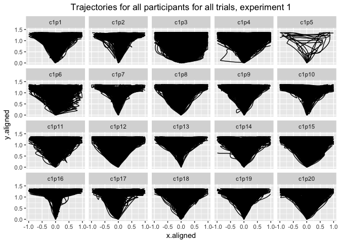

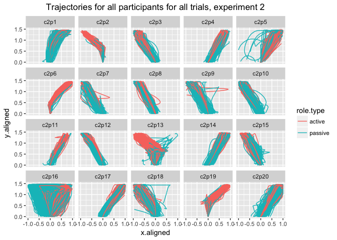

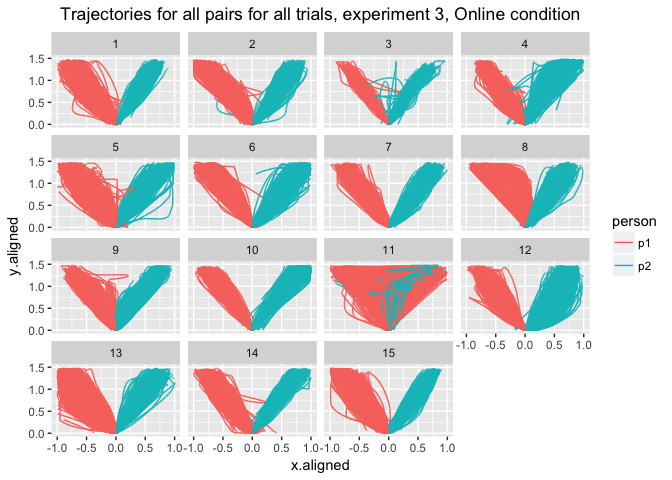

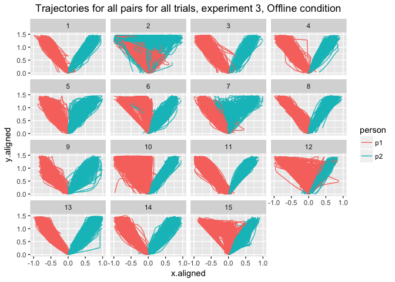

We see that in experiment 1, participant 5 has only few trajectories. We can confirm this by looking at the number of trials this person has:

```r
p5 <- filter(exp1.aligned, personid == "c1p5")
length(unique(p5$trial))
```

```
## [1] 13
```

```r
# removing the participant data
exp1.aligned <- filter(exp1.aligned, personid != "c1p5")
```

In experiment 3, we see that most pairs seem to divide the screen space between each other by moving mostly directly towards their assigned response box and avoiding the center. However, there are exceptions.

In condition with visual feedback one particular pair (11) has mostly upward moving trajectories. We can further explore here whether the joint upward motion is induced by one of the participants or happens immediately on both sides.

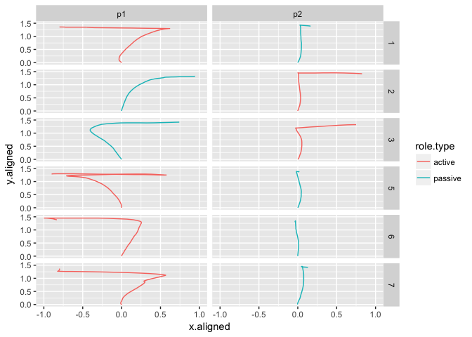

The plot presents trajectories in the first couple of trials (1-7) of two participants from pair 11. The trajectories are colored red for when participant’s role was “active”, i.e. the cue that appeared had their assigned color and blue for when their role was “passive”, i.e. their task in such a trial was to not press the response button and simply go back to the start position.

From the plots it would appear that one of the members of this aberrant couple (person 2) adopts a “move upward” strategy from the start, independently of whether it is their turn to respond or not. The other person in that couple seems to copy the co-actor’s movements on passive trials and make large discrete errors on the trials in which it is actually their turn to respond. Why this particular couple behaves in this manner is unfortunately unknown and might indicate some individual differences, the feeling of jointness experienced by this couple or conscious strategies that people adopt in such a task.

In condition without visual feedback it is rather that certain individuals adopt the “move upward” strategy, independently of their partner (which is to be expected since they do not see the partner’s movements).

**Step 8** Flip trajectories

As the next pre-processing step we will flip all trajectories to one side. This ensures that every trajectory starts at the bottom of the coordinate system and ends in the top right corner. It is done to obtain comparable trajectory measures.

**Step 9** Remove outliers

As a last step, we look at a sampling rate distribution to see whether it reveals any outliers that could indicate missing data or wrong recording.

From the data we can extract all intervals between adjacent sampling points and calculate their mean and standard devation. We then establish a cutoff point of 3 SD from the mean beyond which the sampling interval is considered to be an outlier. We calculate the number of such outliers for each condition and their mean sampling rate. The resulting numbers are presented in the following table.

|  | rate.means | rate.sds | rate.cutoff | num.outliers | mean.outliers |
| --- | --- | --- | --- | --- | --- |
| exp1 | 10.87 | 0.01 | 10.88 | 597 | 10.90 |
| exp2 | 10.87 | 0.01 | 10.91 | 8 | 13.60 |
| exp3:online | 10.87 | 1.13 | 14.26 | 41 | 207.71 |
| exp4:offline | 10.87 | 2.39 | 18.04 | 167 | 216.51 |

It turns out that the mean sampling rate for all experiments is within expected parameters given the set sampling rate of 92 Hz. The number of outliers and their means varies with much larger deviations in experiment 3. Given the cross-computer data stream in the social task, some amount of data loss is to be expected. We remove trials that contain these large deviations.

Next we look at y coordinates that should not be lower than some margin around 0 (after flipping and alignment). A y-coordinate that is more negative indicates a faulty recording of the start button press.

With the sampling timing issues fixed, we can examine reaction time outliers.

**Step 10** Transform into a mousetrap object

For the analysis we will use a mousetrap package so we transform the data frames into mousetrap objects.

**Step 11** Normalize trajectories

As a final pre-processing step, we perform time normalization on the data, in which the times and coordinates are linearly interpolated so that each trajectory contains the same number of recorded points (typically set to 101 points).

**Step 12** Check observation counts

We check whether all participants have a balanced number of observations for different variables of interest by plotting observation counts per person per condition.

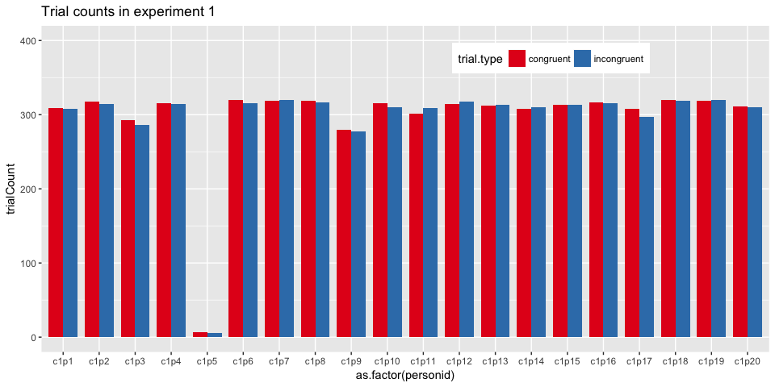

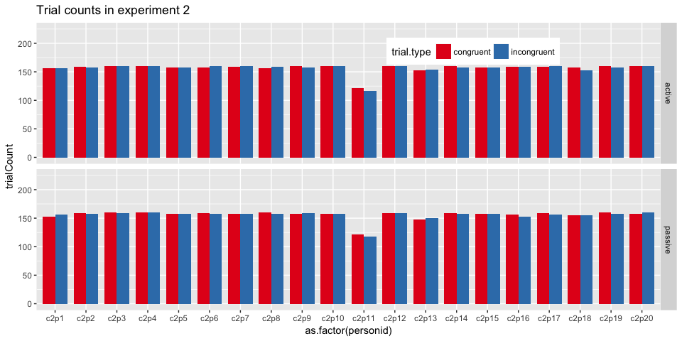

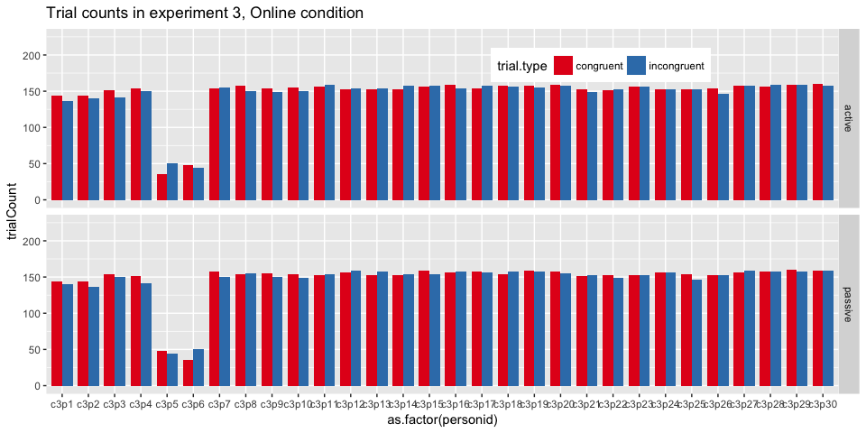

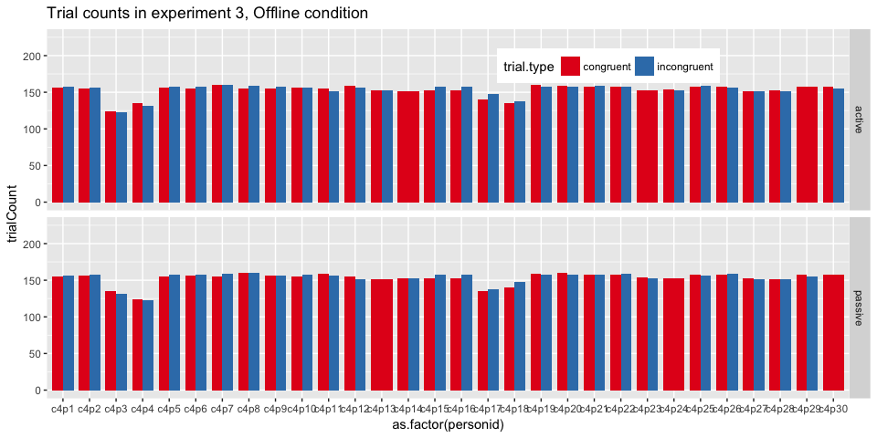

From the counts plot, we can see that in experiments 1 and 2 one person in each has markedly less successful trials than other participants. In experiment 3, Online condition, even though different numbers of trials remain for different pairs after removing unsuccessful ones, there are similar counts for different trial and role types.

By contrast, in experiment 3, Offline condition, three of the pairs completely lose observations for one of the incongruent set of trials, namely participants with ids 14, 23, 29 lose incongruent active trials while their co-actors (ids 13, 24, 30) incongruent passive ones. Further investigation of these counts reveals that the crucial step that leads to this loss is filtering out trials in which incorrect response was given, that is, participant clicked on the wrong response box. Given that this correlates with trials being incongruent (the cue appeared on the same side as the incorrect response box), we might infer that participants 14, 23 and 29 misunderstood the task, i.e. they were responding to the location of the cue, rather than its color. We can confirm this conclusion by plotting the trajectories of these participants.

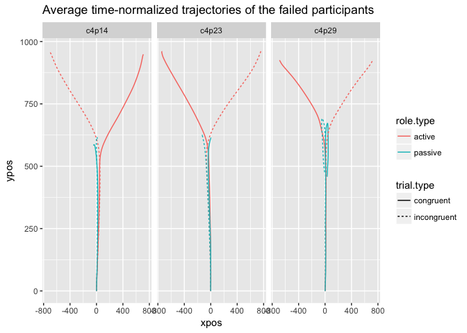

We see that indeed, 3 participants in condition 4 misunderstood the instructions and therefore need to be removed from further analysis.

# Dependent variables calculation

There is a number of measures that can be calculated on the basis of raw time and normalized trajectories. Here we are interested only in the latter, although a more complex analysis could involve looking at measures like velocity that require raw times.

These are the measures that are returned by mousetrap:

| Measure | Definition |
| --- | --- |
| xpos_max | Maximum x-position |
| xpos_min | Minimum x-position |
| ypos_max | Maximum y-position |
| ypos_min | Minimum y-position |
| MAD | Signed Maximum absolute deviation from the direct path connecting start and end point of the trajectory (straight line). If the MAD occurs above the direct path, this is denoted by a positive value; i… |
| MAD_time | Time at which the maximum absolute deviation was reached first |
| MD_above | Maximum deviation above the direct path |
| MD_above_time | Time at which the maximum deviation above was reached first |
| MD_below | Maximum deviation below the direct path |
| MD_below_time | Time at which the maximum deviation below was reached first |
| AD | Average deviation from direct path |
| AUC | Area under curve, the geometric area between the actual trajectory and the direct path where areas below the direct path have been subtracted |
| xpos_flips | Number of directional changes along x-axis (exceeding the distance specified in flip_threshold) |
| ypos_flips | Number of directional changes along y-axis (exceeding the distance specified in flip_threshold) |
| xpos_reversals | Number of crossings of the y-axis |
| ypos_reversals | Number of crossings of the x-axis |
| RT | Response time, time at which tracking stopped |
| initiation_time | Time at which first mouse movement was initiated |
| idle_time | Total time without mouse movement across the entirety of the trial |

Out of these measures, the most widely used are measures of the curvature of mouse trajectories, i.e. MAD, AD and AUC. A variety of time-based measures allows us to examine movement duration in different stages of the trajectory. Finally, coordinate flips and reversals are a proxy for movement complexity (which we later examine with an alternative entropy-based measure).

For the purpose of this paper we focus on the shape of movement trajectories and basic reaction time measure.

Our data for experiments 2 and 3 contains trials in which a participant’s role was ‘active’, i.e., it was their turn to respond to the cue, and trials in which the role was ‘passive’, i.e., their task was to refrain from responding. It is reasonable to assume that different cognitive processes are at play in these types of trials and that different trajectories should result. Therefore, for further analysis we split the data into two groups: active and passive data and we examine them separately.

Finally, we aggregate dependent measures by averaging across trials within each participant for every level of the independent variable (Trial Type).

# Exploratory Analysis

## Reaction time plots

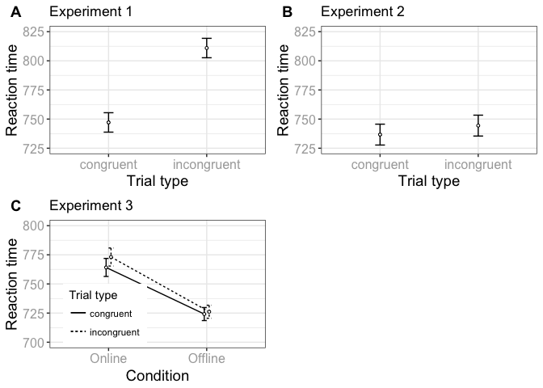

## Trajectory plots

We plot trajectories averaged across trials for each participant and across participants.

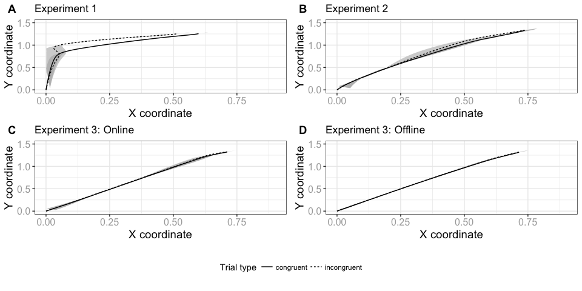

We also plot passive trajectories.

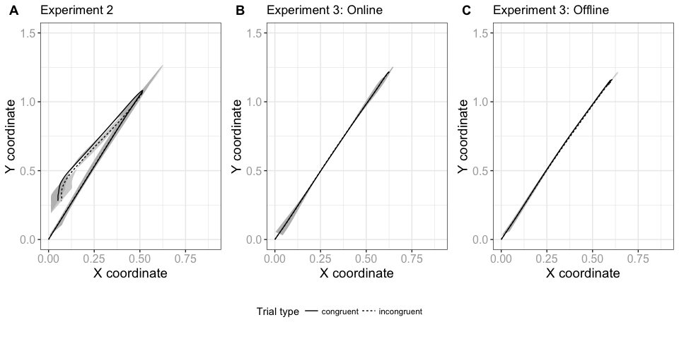

From these plots it would seem that in experiment 1 the trial type affects movement trajectory with incongruent trials taking longer and producing trajectories more deviated towards the wrong response. By contrast, in experiment 2 and 3 both reaction time and trajectories look similar independently of the trial type. Furthermore, in experiment 2 and 3 participants seem to go straight for their assigned response button instead of producing curved trajectories typically found in mouse-tracking studies.

# Statistical analysis

Exploratory analysis suggests that conditions differ in how the type of trial affects participant behavior. There seems to be a notable Simon effect in the individual condition but no effect in individual GoNo-Go condition or social conditions.

In this part we will complement plot-based observations with statistical analysis. The analysis is carried out separately for 2 types of individual conditions and the social conditions.

## Reaction time

The following are results for

- a paired t-test on reaction times from experiment 1
- a paired t-test on reaction times from experiment 2
- a mixed ANOVA on reaction times from experiment 3 (between-subject variable condition and within-subject variable trial type)

```
##
##  Paired t-test
##
## data:  RT by trial.type
## t = -11.387, df = 18, p-value = 5.837e-10
## alternative hypothesis: true difference in means is less than 0
## 95 percent confidence interval:
##       -Inf -54.11587
## sample estimates:
## mean of the differences
##               -63.83683
```

```
##
##  Paired t-test
##
## data:  RT by trial.type
## t = -1.2806, df = 18, p-value = 0.1083
## alternative hypothesis: true difference in means is less than 0
## 95 percent confidence interval:
##      -Inf 2.733843
## sample estimates:
## mean of the differences
##                -7.72143
```

```
## Anova Table (Type 3 tests)
##
## Response: RT
##                 Effect    df      MSE    F   ges pes p.value
## 1            condition 1, 51 31525.70 1.58   .03 .03     .21
## 2           trial.type 1, 51   297.08 2.65 .0005 .05     .11
## 3 condition:trial.type 1, 51   297.08 1.08 .0002 .02     .30
## ---
## Signif. codes:  0 '***' 0.001 '**' 0.01 '*' 0.05 '+' 0.1 ' ' 1
```

We find a significantly larger reaction time in incongruent trials only in experiment 1.

## Area under curve

### Bimodality analysis

Sometimes, averaging trajectories produces artifical results. For example, a smooth average trajectory for a given participant could be a result of a large number of straight trajectories that go directly to the target and discrete error type of trajectories where participant first moves directly to the wrong side and then abruptly changes direction.

The main method to eliminate this possibility relies on bimodality analysis, which checks whether spatial measures are bimodally distributed. This can be determined by looking at histograms of standardized trajectory deviation measures or by calculating a bimodality coefficient.

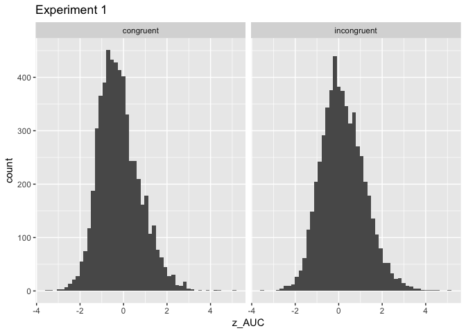

```
## $BC
##    trial.type     z_AUC
## 1   congruent 0.3600507
## 2 incongruent 0.3403739
```

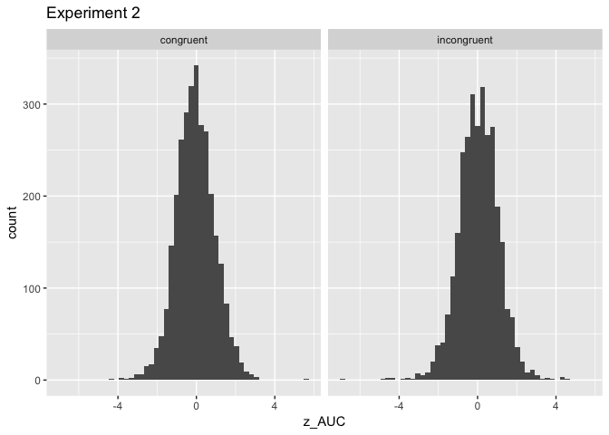

```
## $BC
##    trial.type     z_AUC
## 1   congruent 0.2689672
## 2 incongruent 0.2197816
```

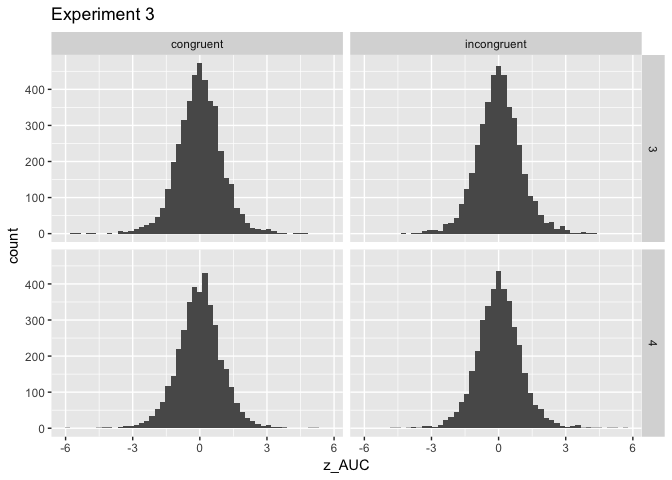

```
## $BC
##    trial.type     z_AUC
## 1   congruent 0.2189006
## 2 incongruent 0.2309513
```

A distribution is considered bimodal if BC > 0.555. In our case neither distribution plots nor bimodality coefficients (which are below 0.555 for all conditions) give any reason to suspect bimodal data that could blur our results.

We therefore proceed with analysis of area under curve measure in experiments 1-3 as with RT measure.

```
##
##  Paired t-test
##
## data:  AUC by trial.type
## t = -6.7295, df = 18, p-value = 1.31e-06
## alternative hypothesis: true difference in means is less than 0
## 95 percent confidence interval:
##         -Inf -0.05666267
## sample estimates:
## mean of the differences
##             -0.07633179
```

```
##
##  Paired t-test
##
## data:  AUC by trial.type
## t = -0.98809, df = 18, p-value = 0.1681
## alternative hypothesis: true difference in means is less than 0
## 95 percent confidence interval:
##         -Inf 0.008074198
## sample estimates:
## mean of the differences
##              -0.0106949
```

```
## Anova Table (Type 3 tests)
##
## Response: AUC
##                 Effect    df  MSE      F    ges   pes p.value
## 1            condition 1, 51 0.03   0.11   .002  .002     .74
## 2           trial.type 1, 51 0.00 3.57 +  .0002   .07     .06
## 3 condition:trial.type 1, 51 0.00   0.02 <.0001 .0003     .90
## ---
## Signif. codes:  0 '***' 0.001 '**' 0.01 '*' 0.05 '+' 0.1 ' ' 1
```

# Individual-level analysis

## Individual trajectory plots

To check whether the patterns we find on the group level also hold on the individual level, we can also examine average trajectories of individual participants.

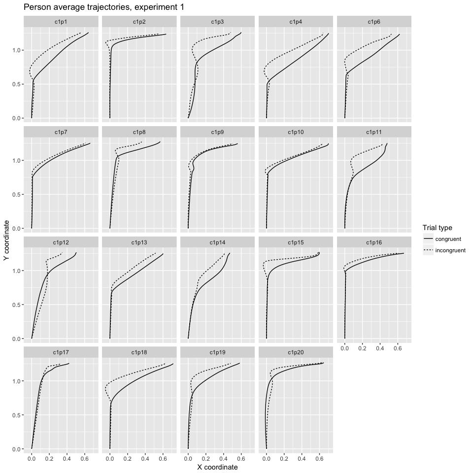

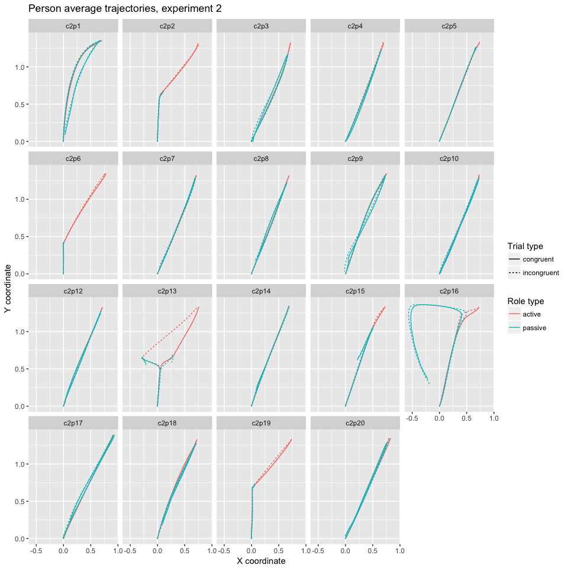

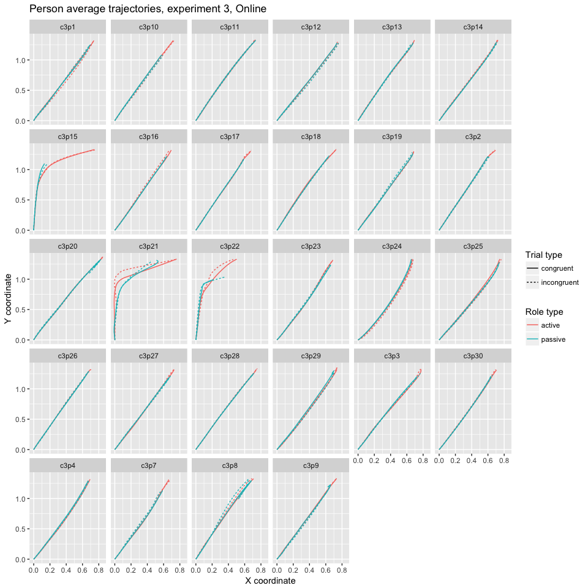

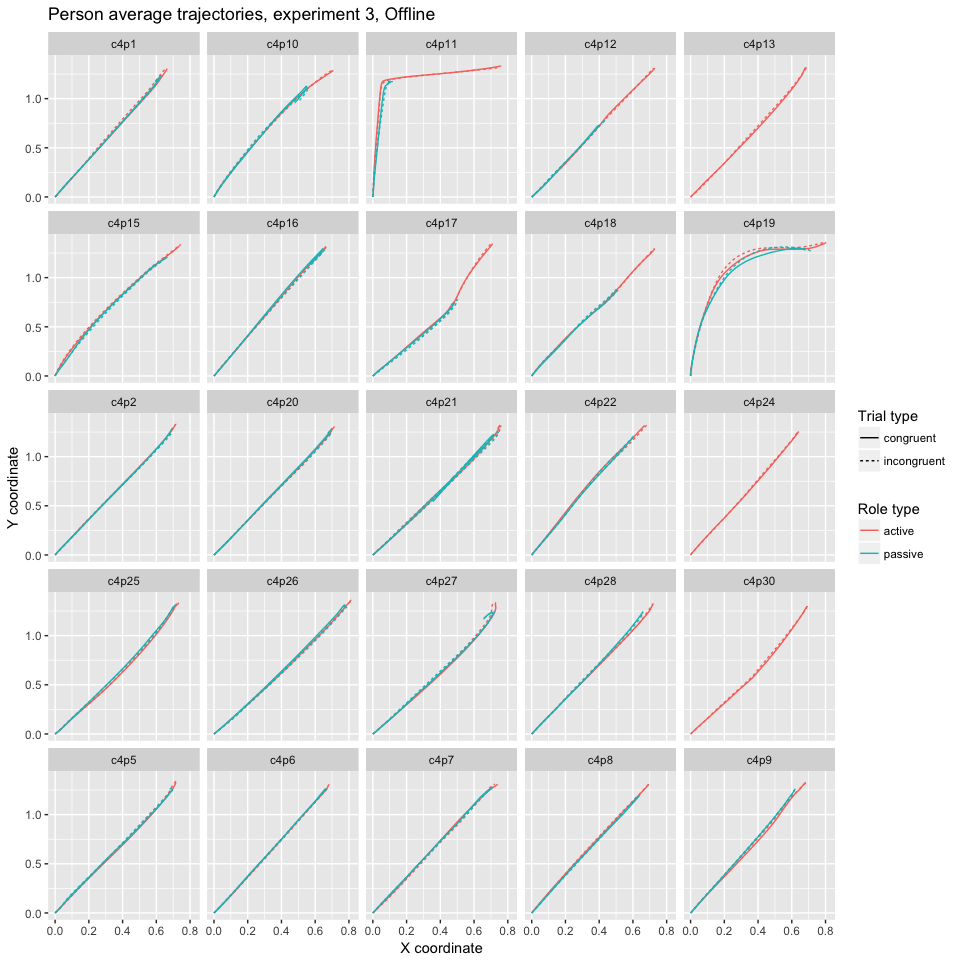

Here we can make several observations.

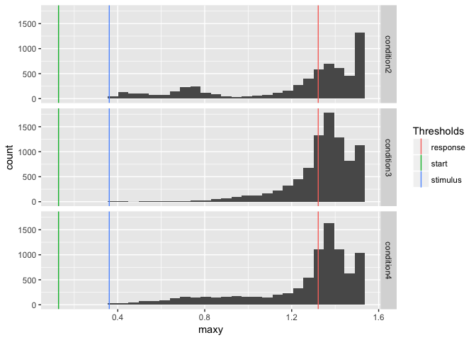

## Trajectory prototypes

In order to examine the qualitative difference between individual trajectories in a more unbiased manner, we can automatically assign participants to straight vs curved motion strategy based on the shape of the majority of their trajectories. Mousetrap package provides a possibility for mapping collected trajectories to a number of trajectory prototypes frequently encountered in mouse tracking experiments, such as these:

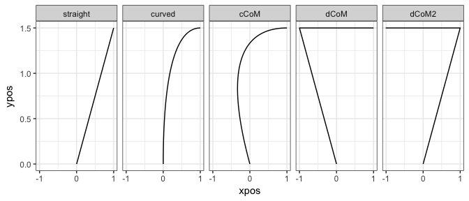

We can map trajectories collected in our experiment to the prototypes and plot them. Given that variability is mostly present in experiments 2 and 3, we focus on this data here.

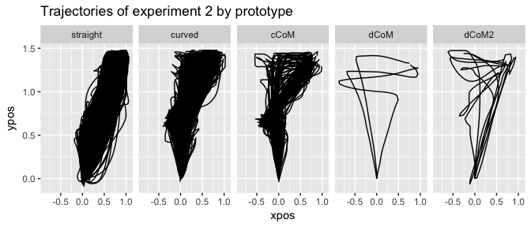

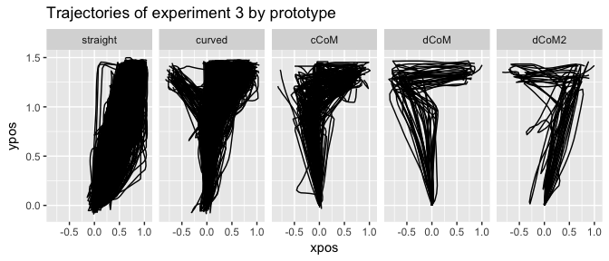

We can also plot the distribution of trajectories for all the individual participants, focusing here on the two main types, “straight” and “curved”+“cCoM” prototypes.

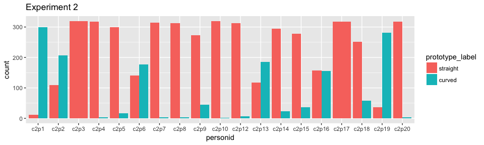

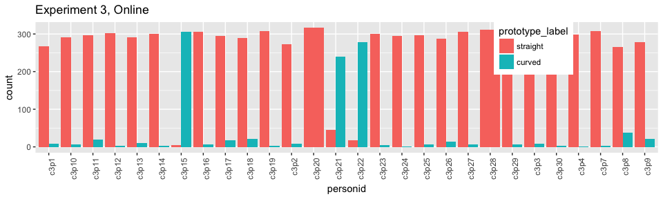

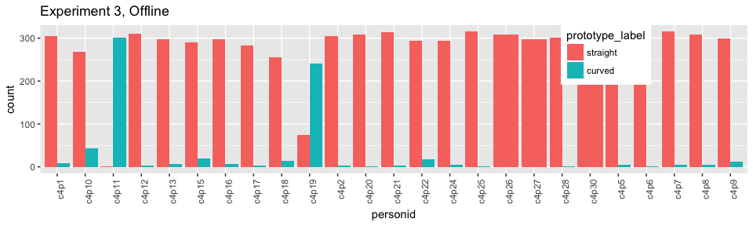

We can now use the prototype information to asign participants to a “straight” or “curved” group. We do this by simple majority i.e., if the majority of a given person’s trajectories are straight, they are assigned to the straight group and analogously for the curved trajectories.

## Individual-level analyses

Since we have seen that participants tend to employ two qualitatively different movement patterns, a question we can ask is whether two groups also lead to qualitatively different statistical results. To that end we run t-tests on the individual level. Our prediction is that curved participants but not straight participants show significantly higher RT and AUC in incongruent trials compared to congruent trials.

| personid | measure | t | df | p | lower.conf | upper.conf | estimate1 | estimate2 | effect | prototype |
| --- | --- | --- | --- | --- | --- | --- | --- | --- | --- | --- |
| c2p1 | RT | 1.330 | 247.8999 | 0.90762 | -Inf | 44.979 | 647.157 | 627.090 | 0.084 | curved |
| c2p1 | AUC | 0.435 | 307.7428 | 0.66800 | -Inf | 0.023 | 0.299 | 0.294 | 0.025 | curved |
| c2p13 | RT | -1.913 | 299.0113 | 0.02834 | -Inf | -10.168 | 1455.521 | 1529.412 | 0.110 | curved |
| c2p13 | AUC | -24.194 | 298.4827 | 0.00000 | -Inf | -0.187 | 0.114 | 0.314 | 0.814 | curved |
| c2p19 | RT | -2.698 | 286.1834 | 0.00370 | -Inf | -22.224 | 913.179 | 970.419 | 0.157 | curved |
| c2p19 | AUC | -3.923 | 300.6781 | 0.00005 | -Inf | -0.014 | 0.221 | 0.245 | 0.221 | curved |
| c2p2 | RT | -1.991 | 312.8708 | 0.02370 | -Inf | -5.337 | 841.910 | 873.074 | 0.112 | curved |
| c2p2 | AUC | -1.939 | 312.0737 | 0.02670 | -Inf | -0.001 | 0.180 | 0.190 | 0.109 | curved |
| c2p6 | RT | -0.570 | 300.6392 | 0.28472 | -Inf | 13.917 | 981.930 | 989.266 | 0.033 | curved |
| c2p6 | AUC | -1.529 | 309.4103 | 0.06365 | -Inf | 0.001 | 0.189 | 0.197 | 0.087 | curved |
| c2p10 | RT | -1.297 | 310.2694 | 0.09773 | -Inf | 6.403 | 576.698 | 600.272 | 0.073 | straight |
| c2p10 | AUC | -1.546 | 308.8431 | 0.06162 | -Inf | 0.001 | -0.028 | -0.016 | 0.088 | straight |
| c2p12 | RT | -0.557 | 308.0955 | 0.28885 | -Inf | 19.441 | 571.196 | 581.114 | 0.032 | straight |
| c2p12 | AUC | -0.041 | 317.9715 | 0.48353 | -Inf | 0.009 | 0.027 | 0.027 | 0.002 | straight |
| c2p14 | RT | 1.098 | 307.8853 | 0.86344 | -Inf | 38.873 | 647.283 | 631.751 | 0.062 | straight |
| c2p14 | AUC | -0.661 | 314.6421 | 0.25467 | -Inf | 0.007 | 0.015 | 0.020 | 0.037 | straight |
| c2p15 | RT | 1.774 | 287.7966 | 0.96148 | -Inf | 75.220 | 793.960 | 754.985 | 0.104 | straight |
| c2p15 | AUC | -0.225 | 308.9611 | 0.41113 | -Inf | 0.012 | 0.067 | 0.069 | 0.013 | straight |
| c2p16 | RT | 0.048 | 315.8738 | 0.51932 | -Inf | 35.921 | 748.770 | 747.744 | 0.003 | straight |
| c2p16 | AUC | 0.059 | 314.7867 | 0.52347 | -Inf | 0.055 | 0.160 | 0.158 | 0.003 | straight |
| c2p17 | RT | -0.740 | 289.5166 | 0.23000 | -Inf | 19.013 | 505.743 | 521.196 | 0.043 | straight |
| c2p17 | AUC | -0.777 | 316.5966 | 0.21875 | -Inf | 0.009 | 0.013 | 0.021 | 0.044 | straight |
| c2p18 | RT | 0.014 | 306.1270 | 0.50546 | -Inf | 39.749 | 716.145 | 715.818 | 0.001 | straight |
| c2p18 | AUC | 2.204 | 303.8850 | 0.98586 | -Inf | 0.044 | 0.086 | 0.061 | 0.125 | straight |
| c2p20 | RT | -1.168 | 304.5004 | 0.12180 | -Inf | 6.944 | 520.109 | 536.956 | 0.067 | straight |
| c2p20 | AUC | 0.435 | 317.7656 | 0.66793 | -Inf | 0.026 | -0.001 | -0.006 | 0.024 | straight |
| c2p3 | RT | 0.536 | 317.9994 | 0.70395 | -Inf | 32.118 | 668.750 | 660.870 | 0.030 | straight |
| c2p3 | AUC | 1.314 | 316.1454 | 0.90511 | -Inf | 0.022 | -0.059 | -0.069 | 0.074 | straight |
| c2p4 | RT | 0.038 | 290.5561 | 0.51517 | -Inf | 27.122 | 783.832 | 783.220 | 0.002 | straight |
| c2p4 | AUC | -1.072 | 317.2109 | 0.14222 | -Inf | 0.003 | -0.022 | -0.016 | 0.060 | straight |
| c2p5 | RT | 0.352 | 312.0240 | 0.63746 | -Inf | 41.007 | 694.001 | 686.790 | 0.020 | straight |
| c2p5 | AUC | 1.135 | 310.6857 | 0.87136 | -Inf | 0.026 | 0.016 | 0.005 | 0.064 | straight |
| c2p7 | RT | 0.545 | 313.4000 | 0.70695 | -Inf | 41.569 | 597.620 | 587.296 | 0.031 | straight |
| c2p7 | AUC | 1.799 | 303.6353 | 0.96350 | -Inf | 0.025 | -0.025 | -0.038 | 0.103 | straight |
| c2p8 | RT | 0.094 | 312.9494 | 0.53731 | -Inf | 40.516 | 691.541 | 689.363 | 0.005 | straight |
| c2p8 | AUC | -0.073 | 312.8495 | 0.47086 | -Inf | 0.010 | -0.006 | -0.006 | 0.004 | straight |
| c2p9 | RT | -0.919 | 310.0276 | 0.17933 | -Inf | 12.249 | 641.712 | 657.127 | 0.052 | straight |
| c2p9 | AUC | 0.178 | 310.2193 | 0.57043 | -Inf | 0.019 | 0.068 | 0.066 | 0.010 | straight |

| personid | measure | t | df | p | lower.conf | upper.conf | estimate1 | estimate2 | effect | prototype |
| --- | --- | --- | --- | --- | --- | --- | --- | --- | --- | --- |
| c3p15 | RT | -1.330 | 305.9785 | 0.09230 | -Inf | 6.658 | 823.698 | 851.350 | 0.076 | curved |
| c3p15 | AUC | -1.380 | 306.0291 | 0.08426 | -Inf | 0.002 | 0.349 | 0.361 | 0.079 | curved |
| c3p21 | RT | -5.522 | 291.3340 | 0.00000 | -Inf | -86.231 | 982.340 | 1105.316 | 0.308 | curved |
| c3p21 | AUC | -2.104 | 291.8940 | 0.01810 | -Inf | -0.012 | 0.358 | 0.414 | 0.122 | curved |
| c3p22 | RT | -0.966 | 293.7321 | 0.16738 | -Inf | 16.636 | 1053.534 | 1077.036 | 0.056 | curved |
| c3p22 | AUC | -2.220 | 291.9261 | 0.01359 | -Inf | -0.007 | 0.279 | 0.307 | 0.129 | curved |
| c4p11 | RT | 0.419 | 291.2212 | 0.66212 | -Inf | 43.106 | 868.290 | 859.566 | 0.025 | curved |
| c4p11 | AUC | -0.360 | 299.7137 | 0.35944 | -Inf | 0.012 | 0.417 | 0.421 | 0.021 | curved |
| c4p19 | RT | -0.118 | 311.5729 | 0.45310 | -Inf | 35.739 | 668.544 | 671.295 | 0.007 | curved |
| c4p19 | AUC | -1.148 | 310.6841 | 0.12591 | -Inf | 0.011 | 0.370 | 0.395 | 0.065 | curved |
| c3p1 | RT | 0.991 | 273.2223 | 0.83868 | -Inf | 60.792 | 845.586 | 822.781 | 0.060 | straight |
| c3p1 | AUC | 2.483 | 273.5272 | 0.99318 | -Inf | 0.045 | -0.006 | -0.032 | 0.148 | straight |
| c3p10 | RT | -1.013 | 276.0934 | 0.15598 | -Inf | 18.002 | 857.632 | 886.242 | 0.061 | straight |
| c3p10 | AUC | 0.949 | 274.5159 | 0.82825 | -Inf | 0.019 | 0.006 | -0.001 | 0.057 | straight |
| c3p11 | RT | -0.736 | 295.8101 | 0.23130 | -Inf | 18.840 | 646.178 | 661.331 | 0.043 | straight |
| c3p11 | AUC | -0.297 | 296.8211 | 0.38337 | -Inf | 0.012 | 0.031 | 0.033 | 0.017 | straight |
| c3p12 | RT | -1.822 | 289.4142 | 0.03475 | -Inf | -3.902 | 687.782 | 729.180 | 0.106 | straight |
| c3p12 | AUC | -1.357 | 297.9425 | 0.08791 | -Inf | 0.002 | -0.024 | -0.013 | 0.078 | straight |
| c3p13 | RT | 1.083 | 298.9992 | 0.86006 | -Inf | 45.947 | 650.628 | 632.425 | 0.062 | straight |
| c3p13 | AUC | 0.643 | 292.5906 | 0.73974 | -Inf | 0.018 | 0.013 | 0.008 | 0.038 | straight |
| c3p14 | RT | -0.125 | 301.4069 | 0.45032 | -Inf | 36.973 | 695.874 | 698.904 | 0.007 | straight |
| c3p14 | AUC | 0.871 | 294.7539 | 0.80789 | -Inf | 0.012 | -0.015 | -0.019 | 0.051 | straight |
| c3p16 | RT | 0.679 | 306.9587 | 0.75104 | -Inf | 58.579 | 910.080 | 893.009 | 0.039 | straight |
| c3p16 | AUC | -0.011 | 308.9997 | 0.49580 | -Inf | 0.010 | -0.008 | -0.008 | 0.001 | straight |
| c3p17 | RT | 0.400 | 307.4933 | 0.65523 | -Inf | 42.931 | 811.049 | 802.674 | 0.023 | straight |
| c3p17 | AUC | -0.249 | 306.8774 | 0.40189 | -Inf | 0.015 | 0.005 | 0.008 | 0.014 | straight |
| c3p18 | RT | -0.454 | 308.8503 | 0.32520 | -Inf | 29.985 | 708.539 | 719.911 | 0.026 | straight |
| c3p18 | AUC | 1.396 | 308.6144 | 0.91813 | -Inf | 0.019 | 0.045 | 0.036 | 0.079 | straight |
| c3p19 | RT | -0.199 | 307.9039 | 0.42108 | -Inf | 22.338 | 562.427 | 565.497 | 0.011 | straight |
| c3p19 | AUC | 0.686 | 307.9990 | 0.75336 | -Inf | 0.014 | -0.009 | -0.014 | 0.039 | straight |

[output cut: 76 more lines]

## Sample entropy

In some cases, it may be helpful to measure the complexity of mouse trajectories. For example, if both response alternatives simultaneously attract participants’ mouse movement (relative to only one), this additional stress might manifest as less smooth, more complex, and fluctuating trajectories. One of the measures of trajectory complexity is sample entropy, which is based on predictability of trajectory given a number of surrounding coordinates. We calculate sample entropy for all the data using a function provided by the mousetrap package with default settings. It is calculated for all individual trajectories and then we average across trajectories to obtain measures for each participant, separately for different data types and separately for active and passive trials (in experiments 2 and 3).

Having obtained sample entropy measure we can subject it to standard statistical analyses. We compare the measures for congruent and incongruent trials (experiments 1-3) and for passive and active trials (experiments 2 and 3).

```
##
##  Paired t-test
##
## data:  sample_entropy by trial.type
## t = -9.115, df = 18, p-value = 3.644e-08
## alternative hypothesis: true difference in means is not equal to 0
## 95 percent confidence interval:
##  -0.0327411 -0.0204752
## sample estimates:
## mean of the differences
##             -0.02660815
```

```
## Anova Table (Type 3 tests)
##
## Response: sample_entropy
##                 Effect    df  MSE    F   ges pes p.value
## 1           trial.type 1, 16 0.00 2.50 .0005 .14     .13
## 2            role.type 1, 16 0.00 2.18   .06 .12     .16
## 3 trial.type:role.type 1, 16 0.00 1.11 .0005 .06     .31
## ---
## Signif. codes:  0 '***' 0.001 '**' 0.01 '*' 0.05 '+' 0.1 ' ' 1
```

```
## Anova Table (Type 3 tests)
##
## Response: sample_entropy
##                 Effect    df  MSE    F   ges  pes p.value
## 1            condition 1, 48 0.00 0.40  .008 .008     .53
## 2           trial.type 1, 48 0.00 1.09 .0002  .02     .30
## 3 condition:trial.type 1, 48 0.00 0.63 .0001  .01     .43
## ---
## Signif. codes:  0 '***' 0.001 '**' 0.01 '*' 0.05 '+' 0.1 ' ' 1
```

In experiment 1 we see a highly significant difference in sample entropy between congruent and incongruent trials, indicating that participants’ movement in incongruent trials was more erratic. By contrast, in experiments 2 and 3, there seems to be no effect on movement entropy by either role or trial type. Thus, entropy measure replicates the results of RTs and trajectory deviation.